# R Notebook

This question should be answered using the Weekly data set, which is part of the ISLR package. This data is similar in nature to the Smarket data from this chapter’s lab, except that it contains 1,089 weekly returns for 21 years, from the beginning of 1990 to the end of 2010.

```r
summary(new_Weekly)
```

```
      Year           Lag1               Lag2               Lag3
 Min.   :1990   Min.   :-18.1950   Min.   :-18.1950   Min.   :-18.1950
 1st Qu.:1995   1st Qu.: -1.1540   1st Qu.: -1.1540   1st Qu.: -1.1580
 Median :2000   Median :  0.2410   Median :  0.2410   Median :  0.2410
 Mean   :2000   Mean   :  0.1506   Mean   :  0.1511   Mean   :  0.1472
 3rd Qu.:2005   3rd Qu.:  1.4050   3rd Qu.:  1.4090   3rd Qu.:  1.4090
 Max.   :2010   Max.   : 12.0260   Max.   : 12.0260   Max.   : 12.0260
      Lag4               Lag5              Volume            Today          Direction
 Min.   :-18.1950   Min.   :-18.1950   Min.   :0.08747   Min.   :-18.1950   Down:484
 1st Qu.: -1.1580   1st Qu.: -1.1660   1st Qu.:0.33202   1st Qu.: -1.1540   Up  :605
 Median :  0.2380   Median :  0.2340   Median :1.00268   Median :  0.2410
 Mean   :  0.1458   Mean   :  0.1399   Mean   :1.57462   Mean   :  0.1499
 3rd Qu.:  1.4090   3rd Qu.:  1.4050   3rd Qu.:2.05373   3rd Qu.:  1.4050
 Max.   : 12.0260   Max.   : 12.0260   Max.   :9.32821   Max.   : 12.0260
```

1. Produce some numerical and graphical summaries of the Weekly data. Do there appear to be any patterns?

```r
summary(new_Weekly)
```

```
      Year           Lag1               Lag2               Lag3
 Min.   :1990   Min.   :-18.1950   Min.   :-18.1950   Min.   :-18.1950
 1st Qu.:1995   1st Qu.: -1.1540   1st Qu.: -1.1540   1st Qu.: -1.1580
 Median :2000   Median :  0.2410   Median :  0.2410   Median :  0.2410
 Mean   :2000   Mean   :  0.1506   Mean   :  0.1511   Mean   :  0.1472
 3rd Qu.:2005   3rd Qu.:  1.4050   3rd Qu.:  1.4090   3rd Qu.:  1.4090
 Max.   :2010   Max.   : 12.0260   Max.   : 12.0260   Max.   : 12.0260
      Lag4               Lag5              Volume            Today          Direction
 Min.   :-18.1950   Min.   :-18.1950   Min.   :0.08747   Min.   :-18.1950   Down:484
 1st Qu.: -1.1580   1st Qu.: -1.1660   1st Qu.:0.33202   1st Qu.: -1.1540   Up  :605
 Median :  0.2380   Median :  0.2340   Median :1.00268   Median :  0.2410
 Mean   :  0.1458   Mean   :  0.1399   Mean   :1.57462   Mean   :  0.1499
 3rd Qu.:  1.4090   3rd Qu.:  1.4050   3rd Qu.:2.05373   3rd Qu.:  1.4050
 Max.   : 12.0260   Max.   : 12.0260   Max.   :9.32821   Max.   : 12.0260
```

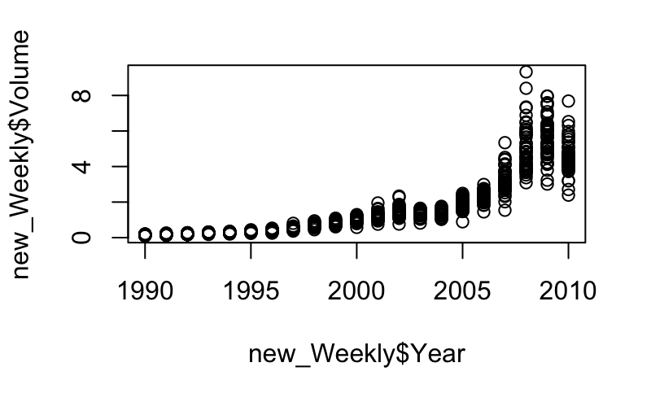

```r
c <- plot(x=new_Weekly$Year, y=new_Weekly$Volume)
```

```r
c
```

[figure not shown]

```r
#new_Weekly$Direction <- unclass(Weekly$Direction)
pairs(new_Weekly)
```

2. Use the full data set to perform a logistic regression with Direction as the response and the five lag variables plus Volume as predictors. Use the summary function to print the results. Do any of the predictors appear to be statistically significant? If so, which ones?

```r
convert_to_binomial <- function(x) {
    if (x == 'Up'){
      return(1)
    } else if (x == 'Down'){
      return(0)
    }
}
new_Weekly$Direction <- sapply(X=new_Weekly$Direction, FUN = convert_to_binomial)
model_1b <- glm(Direction~Lag1+Lag2+Lag3+Lag4+Lag5+Volume,family=binomial(link='logit'),data=new_Weekly)
summary(model_1b)
```

```
Call:
glm(formula = Direction ~ Lag1 + Lag2 + Lag3 + Lag4 + Lag5 +
    Volume, family = binomial(link = "logit"), data = new_Weekly)

Deviance Residuals:
    Min       1Q   Median       3Q      Max
-1.6949  -1.2565   0.9913   1.0849   1.4579

Coefficients:
            Estimate Std. Error z value Pr(>|z|)
(Intercept)  0.26686    0.08593   3.106   0.0019 **
Lag1        -0.04127    0.02641  -1.563   0.1181
Lag2         0.05844    0.02686   2.175   0.0296 *
Lag3        -0.01606    0.02666  -0.602   0.5469
Lag4        -0.02779    0.02646  -1.050   0.2937
Lag5        -0.01447    0.02638  -0.549   0.5833
Volume      -0.02274    0.03690  -0.616   0.5377
---
Signif. codes:  0 ‘***’ 0.001 ‘**’ 0.01 ‘*’ 0.05 ‘.’ 0.1 ‘ ’ 1

(Dispersion parameter for binomial family taken to be 1)

    Null deviance: 1496.2  on 1088  degrees of freedom
Residual deviance: 1486.4  on 1082  degrees of freedom
AIC: 1500.4

Number of Fisher Scoring iterations: 4
```

3. Compute the confusion matrix and overall fraction of correct predictions. Explain what the confusion matrix is telling you about the types of mistakes made by logistic regression.

```r
#suppressMessages(install.packages("caret", dependencies = c("Depends", "Suggests")))
library(caret)

c_pre2 <- predict(model_1b, type="response")
class_prediction <-
  ifelse(c_pre2 > 0.50,
         1,
         0
  )
confusionMatrix(data=factor(class_prediction),reference=factor(new_Weekly$Direction))
```

```
Confusion Matrix and Statistics

          Reference
Prediction   0   1
         0  54  48
         1 430 557

               Accuracy : 0.5611
                 95% CI : (0.531, 0.5908)
    No Information Rate : 0.5556
    P-Value [Acc > NIR] : 0.369

                  Kappa : 0.035

 Mcnemar's Test P-Value : <2e-16

            Sensitivity : 0.11157
            Specificity : 0.92066
         Pos Pred Value : 0.52941
         Neg Pred Value : 0.56434
             Prevalence : 0.44444
         Detection Rate : 0.04959
   Detection Prevalence : 0.09366
      Balanced Accuracy : 0.51612

       'Positive' Class : 0
```

This model seems very inclined to predict an upward movement.

4. Now fit the logistic regression model using a training data period from 1990 to 2008, with Lag2 as the only predictor. Compute the confusion matrix and the overall fraction of correct predictions for the held out data (that is, the data from 2009 and 2010).

```r
q1d_train_slice <- subset(new_Weekly, Year>1989 & Year<2009)
q1d_test_slice <- subset(new_Weekly, Year>2008)
model_1d <- glm(Direction~Lag2,family=binomial(link='logit'),data=q1d_train_slice)

c_pre3<-predict(model_1d, newdata=q1d_test_slice, type="response")
class_prediction_3 <-
  ifelse(c_pre3 > 0.50,
         1,
         0
  )

confusionMatrix(data=factor(class_prediction_3),reference=factor(q1d_test_slice$Direction))
```

```
Confusion Matrix and Statistics

          Reference
Prediction  0  1
         0  9  5
         1 34 56

               Accuracy : 0.625
                 95% CI : (0.5247, 0.718)
    No Information Rate : 0.5865
    P-Value [Acc > NIR] : 0.2439

                  Kappa : 0.1414

 Mcnemar's Test P-Value : 7.34e-06

            Sensitivity : 0.20930
            Specificity : 0.91803
         Pos Pred Value : 0.64286
         Neg Pred Value : 0.62222
             Prevalence : 0.41346
         Detection Rate : 0.08654
   Detection Prevalence : 0.13462
      Balanced Accuracy : 0.56367

       'Positive' Class : 0
```

5. Repeat (d) using LDA.

```r
model_1e <- lda(Direction~Lag2,data=q1d_train_slice)

c_pre_q1e<-predict(model_1e, newdata=q1d_test_slice)
class_prediction_4 <-
  ifelse(c_pre_q1e[["x"]] > 0.50,
         1,
         0
  )

confusionMatrix(data=c_pre_q1e$class,reference=factor(q1d_test_slice$Direction))
```

```
Confusion Matrix and Statistics

          Reference
Prediction  0  1
         0  9  5
         1 34 56

               Accuracy : 0.625
                 95% CI : (0.5247, 0.718)
    No Information Rate : 0.5865
    P-Value [Acc > NIR] : 0.2439

                  Kappa : 0.1414

 Mcnemar's Test P-Value : 7.34e-06

            Sensitivity : 0.20930
            Specificity : 0.91803
         Pos Pred Value : 0.64286
         Neg Pred Value : 0.62222
             Prevalence : 0.41346
         Detection Rate : 0.08654
   Detection Prevalence : 0.13462
      Balanced Accuracy : 0.56367

       'Positive' Class : 0
```

6. Repeat (d) using QDA.

```r
model_1f <- qda(Direction~Lag2,data=q1d_train_slice)

c_pre_q1f<-predict(model_1f, newdata=q1d_test_slice)


confusionMatrix(data=c_pre_q1f$class,reference=factor(q1d_test_slice$Direction))
```

```
Confusion Matrix and Statistics

          Reference
Prediction  0  1
         0  0  0
         1 43 61

               Accuracy : 0.5865
                 95% CI : (0.4858, 0.6823)
    No Information Rate : 0.5865
    P-Value [Acc > NIR] : 0.5419

                  Kappa : 0

 Mcnemar's Test P-Value : 1.504e-10

            Sensitivity : 0.0000
            Specificity : 1.0000
         Pos Pred Value :    NaN
         Neg Pred Value : 0.5865
             Prevalence : 0.4135
         Detection Rate : 0.0000
   Detection Prevalence : 0.0000
      Balanced Accuracy : 0.5000

       'Positive' Class : 0
```

7. Repeat (d) using KNN with K = 1.

```r
library(class)
train.X <- matrix(q1d_train_slice$Lag2)
test.X <- matrix(q1d_test_slice$Lag2)
train.direction <- q1d_train_slice$Direction
test.direction <- q1d_test_slice$Direction

set.seed (1)
knn.pred=knn(train=train.X,test=test.X,cl=train.direction ,k=1)
confusionMatrix(data=knn.pred,reference=factor(q1d_test_slice$Direction))
```

```
Confusion Matrix and Statistics

          Reference
Prediction  0  1
         0 21 30
         1 22 31

               Accuracy : 0.5
                 95% CI : (0.4003, 0.5997)
    No Information Rate : 0.5865
    P-Value [Acc > NIR] : 0.9700

                  Kappa : -0.0033

 Mcnemar's Test P-Value : 0.3317

            Sensitivity : 0.4884
            Specificity : 0.5082
         Pos Pred Value : 0.4118
         Neg Pred Value : 0.5849
             Prevalence : 0.4135
         Detection Rate : 0.2019
   Detection Prevalence : 0.4904
      Balanced Accuracy : 0.4983

       'Positive' Class : 0
```

8. Which of these methods appears to provide the best results on this data? It seems like LDA and Logistic regression provide the exact same results with an accuracy of 62%. I would just one of these since they have the greatest accuracy of all the models.
9. Experiment with different combinations of predictors, including possible transformations and interactions, for each of the methods. Report the variables, method, and associated confusion matrix that appears to provide the best results on the held out data. Note that you should also experiment with values for K in the KNN classifier.